# Lesson 08: Statistical Inference Estimation for Single Populations

25 August, 2018

# Estimation for Single Populations

## 1.) Confidence Interval

> Assume a random sample of size 100 is drawn from a normal distribution with variance 1. The average value of the sample is 50. Find a 95% confidence interval for the mean.

```r
n <- 100 # sample size
mean <- 50 # mean of sample
sd <- sqrt(1) # standard deviation of population
margin.of.error <- normal_z(.95) * sd / sqrt(n)

conf.int <- c(mean - margin.of.error, mean + margin.of.error)

pretty_vector( conf.int )
```

*49.8* and *50.2*

## 2.)

> Assume the standard deviation for a normal distribution is equal to 100 units. Also assume we want to estimate the unknown mean with a 95% confidence interval of total width 8 units. Calculate the sample size required.

```r
z_score <- qnorm(0.025, mean = 0, sd = 1, lower.tail = F)
sample_size <- sample_size <- ( z_score * 100 / 4 ) ** 2

pretty_vector(sample_size)
```

*2401*

## 3.)

> A random sample of 1600 registered voters are contacted and asked a variety of questions. For one question, 60% of the voters expressed approval and 40% disapproval. Calculate a 95% confidence interval for the proportion expressing approval.

```r
# Here we will use a built-in R function for testing a proportion.
# prop.test(x, n, p = NULL,
# alternative = c("two.sided", "less", "greater"),
# conf.level = 0.95, correct = TRUE
# x a vector of counts of successes, a one-dimensional table with two entries,
# or a two-dimensional table (or matrix) with 2 columns, giving the counts of
# successes and failures, respectively.
# n a vector of counts of trials; ignored if x is a matrix or a table.
# p a vector of probabilities of success. The length of p must be the same
# as the number of groups specified by x, and its elements must be greater
# than 0 and less than 1.
# alternative: a character string specifying the alternative hypothesis,
# must be one of "two.sided" (default), "greater" or "less". You can specify
# just the initial letter. Only used for testing the null that a single proportion
# equals a given value, or that two proportions are equal; ignored otherwise.
# conf.level: confidence level of the returned confidence interval.
# Must be a single number between 0 and 1. Only used when testing the
# null that a single proportion equals a given value, or that two proportions
# are equal; ignored otherwise.
# correct: a logical indicating whether Yates' continuity correction should be
# applied where possible.

prop_test_object <- prop.test(x = 1600 * 0.6, n = 1600,
    alternative = "two.sided", conf.level = 0.95)

str(prop_test_object)
```

```
## List of 9
##  $ statistic  : Named num 63.6
##   ..- attr(*, "names")= chr "X-squared"
##  $ parameter  : Named int 1
##   ..- attr(*, "names")= chr "df"
##  $ p.value    : num 1.52e-15
##  $ estimate   : Named num 0.6
##   ..- attr(*, "names")= chr "p"
##  $ null.value : Named num 0.5
##   ..- attr(*, "names")= chr "p"
##  $ conf.int   : num [1:2] 0.575 0.624
##   ..- attr(*, "conf.level")= num 0.95
##  $ alternative: chr "two.sided"
##  $ method     : chr "1-sample proportions test with continuity correction"
##  $ data.name  : chr "1600 * 0.6 out of 1600, null probability 0.5"
##  - attr(*, "class")= chr "htest"
```

```r
# Notice that this object is a list and the confidence interval lower
# and uppler limits themselves can be extracted from the object as
pretty_vector( as.numeric(prop_test_object$conf.int))
```

*0.5755* and *0.624*

## 4.)

> A random sample of consumers are presented with two beverages in random order and asked which they prefer most. All the consumers expressed a preference. One beverage was preferred 85% of the time. Use this number to determine how large a sample of consumers would be needed to generate a 95% confidence interval with an overall width just less than 2% (i.e. from 84% to 86%)?

```r
p <- 0.85
z_score <- qnorm(0.025, mean = 0, sd = 1, lower.tail = FALSE)
sample_size <- (z_score ** 2) * p * (1 - p) / (0.01) ** 2
round(sample_size)
```

```
## [1] 4898
```

```r
sample_size <- (z_score ** 2) * (0.25) / (0.01) ** 2
round(sample_size)
```

```
## [1] 9604
```

# Data Analysis

> Results of a laboratory analysis of calories and sodium content of major hot dog brands. Researchers for Consumer Reports analyzed three types of hot dog: beef, poultry, and meat (mostly pork and beef, but up to 15% poultry meat). Fifty four observations are reported.

```r
hotdogs <- loadDataFile("hot_dogs.csv")
```

## 1.)

> Create boxplots and find 95% confidence intervals for the mean amount of calories in each Type of hot dog: beef, meat and poultry. Construct 99% one-sided lower confidence intervals for the mean amount of calories in each Type of hot dog: beef, meat and poultry.

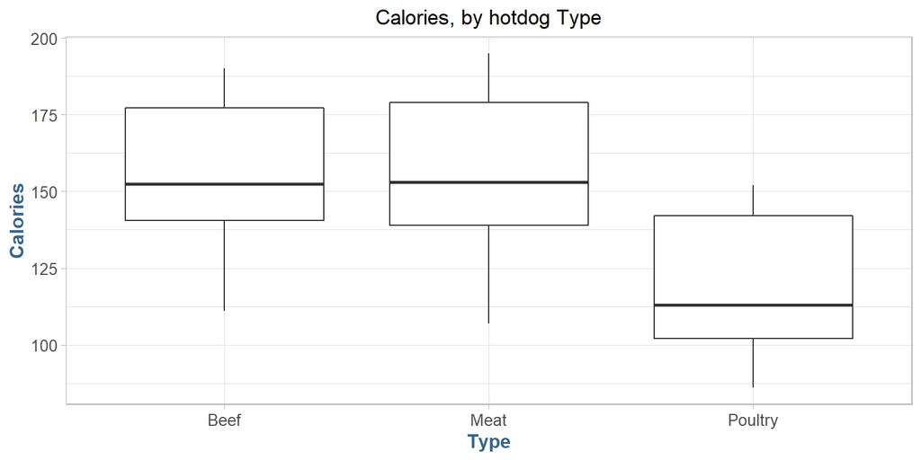

```r
ggplot(hotdogs, aes(x = Type, y = Calories, group = Type)) +
    geom_boxplot() +
    labs(title = "Calories, by hotdog Type")
```

```r
beef <- hotdogs[Type == "Beef"]
meat <- hotdogs[Type == "Meat"]
poultry <- hotdogs[Type == "Poultry"]

with(beef, t.test(Calories)$conf.int)
```

```
## [1] 146.2532 167.4468
## attr(,"conf.level")
## [1] 0.95
```

```r
with(meat, t.test(Calories)$conf.int)
```

```
## [1] 145.7308 171.6809
## attr(,"conf.level")
## [1] 0.95
```

```r
with(poultry, t.test(Calories)$conf.int)
```

```
## [1] 107.1698 130.3596
## attr(,"conf.level")
## [1] 0.95
```

```r
t.test(beef$Calories, alternative = "less", conf.int = 0.99)
```

```
##
##  One Sample t-test
##
## data:  beef$Calories
## t = 30.98, df = 19, p-value = 1
## alternative hypothesis: true mean is less than 0
## 95 percent confidence interval:
##      -Inf 165.6044
## sample estimates:
## mean of x
##    156.85
```

```r
t.test(meat$Calories, alternative = "less", conf.int = 0.99)
```

```
##
##  One Sample t-test
##
## data:  meat$Calories
## t = 25.93, df = 16, p-value = 1
## alternative hypothesis: true mean is less than 0
## 95 percent confidence interval:
##      -Inf 169.3917
## sample estimates:
## mean of x
##  158.7059
```

```r
t.test(poultry$Calories, alternative = "less", conf.int = 0.99)
```

```
##
##  One Sample t-test
##
## data:  poultry$Calories
## t = 21.714, df = 16, p-value = 1
## alternative hypothesis: true mean is less than 0
## 95 percent confidence interval:
##      -Inf 128.3139
## sample estimates:
## mean of x
##  118.7647
```

## 2.)

> Find a 95% confidence interval for the variance in the amount of calories found for each type of hotdog: beef, meat and poultry.

```r
var.conf.int = function(x, conf.level = 0.95) {
    df <- length(x) - 1
    chilower <- qchisq((1 - conf.level) / 2, df, lower.tail = TRUE)
    chiupper <- qchisq((1 - conf.level) / 2, df, lower.tail = FALSE)
    v <- var(x)
    c(df * v / chiupper, df * v / chilower)
}

pretty_vector(with(beef, var.conf.int(Calories)))
```

*296.5* and *1094*

```r
pretty_vector(with(meat, var.conf.int(Calories)))
```

*353.2* and *1475*

```r
pretty_vector(with(poultry, var.conf.int(Calories)))
```

*282.1* and *1178*